# LME - Tutorial 1

2023-05-24

# Linear models and linear mixed effects models in R: Tutorial 1

Assume you knew nothing about males and females, and you were interested in whether the voice pitch of males and females differs, and if so, by how much.

- pitch ~ sex “pitch predicted by sex” or “pitch as a function of sex”
- dependent ~ independent (predictor/explanatory)
- pitch ~ sex + $\epsilon$ (random factors)
- formula divided into stuff you can understand (fixed effects) and stuff you can’t understand (random part “epsilon”)

```r
pitch = c(233,204,242,130,112,142)
sex = c(rep("female",3),rep("male",3))
my.df = data.frame(sex,pitch)
my.df
```

```
##      sex pitch
## 1 female   233
## 2 female   204
## 3 female   242
## 4   male   130
## 5   male   112
## 6   male   142
```

```r
xmdl = lm(pitch ~ sex, my.df) # don't need to specify error term
summary(xmdl)
```

```
##
## Call:
## lm(formula = pitch ~ sex, data = my.df)
##
## Residuals:
##       1       2       3       4       5       6
##   6.667 -22.333  15.667   2.000 -16.000  14.000
##
## Coefficients:
##             Estimate Std. Error t value Pr(>|t|)
## (Intercept)   226.33      10.18  22.224 2.43e-05 ***
## sexmale       -98.33      14.40  -6.827  0.00241 **
## ---
## Signif. codes:  0 '***' 0.001 '**' 0.01 '*' 0.05 '.' 0.1 ' ' 1
##
## Residual standard error: 17.64 on 4 degrees of freedom
## Multiple R-squared:  0.921,  Adjusted R-squared:  0.9012
## F-statistic: 46.61 on 1 and 4 DF,  p-value: 0.002407
```

# example with continuous factor (age)

```r
age = c(14,23,35,48,52,67)
pitch = c(252,244,240,233,212,204)
my.df = data.frame(age,pitch)
xmdl = lm(pitch ~ age, my.df)
summary(xmdl)
```

```
##
## Call:
## lm(formula = pitch ~ age, data = my.df)
##
## Residuals:
##      1      2      3      4      5      6
## -2.338 -2.149  4.769  9.597 -7.763 -2.115
##
## Coefficients:
##             Estimate Std. Error t value Pr(>|t|)
## (Intercept) 267.0765     6.8522   38.98 2.59e-06 ***
## age          -0.9099     0.1569   -5.80  0.00439 **
## ---
## Signif. codes:  0 '***' 0.001 '**' 0.01 '*' 0.05 '.' 0.1 ' ' 1
##
## Residual standard error: 6.886 on 4 degrees of freedom
## Multiple R-squared:  0.8937, Adjusted R-squared:  0.8672
## F-statistic: 33.64 on 1 and 4 DF,  p-value: 0.004395
```

- intercept estimate = predicted pitch value for people with age 0… so not very interesting and the p value is meaningless
- age estimate -0.9099 = for every increase of age by 1, you decrease voice pitch by 0.9099 Hz

# Meaningful and meaningless intercepts

**center the data** to make the intercept meaningful: subtract the mean age from each age value

```r
my.df$age.c = my.df$age - mean(my.df$age)
xmdl = lm(pitch ~ age.c, my.df)
summary(xmdl)
```

```
##
## Call:
## lm(formula = pitch ~ age.c, data = my.df)
##
## Residuals:
##      1      2      3      4      5      6
## -2.338 -2.149  4.769  9.597 -7.763 -2.115
##
## Coefficients:
##             Estimate Std. Error t value Pr(>|t|)
## (Intercept) 230.8333     2.8113   82.11 1.32e-07 ***
## age.c        -0.9099     0.1569   -5.80  0.00439 **
## ---
## Signif. codes:  0 '***' 0.001 '**' 0.01 '*' 0.05 '.' 0.1 ' ' 1
##
## Residual standard error: 6.886 on 4 degrees of freedom
## Multiple R-squared:  0.8937, Adjusted R-squared:  0.8672
## F-statistic: 33.64 on 1 and 4 DF,  p-value: 0.004395
```

- intercept is now the predicted boice pitch at the average age
- slope and significance haven’t changed
- haven’t changed the model, just the metrics to make the intercept more meaningful
- easy to scale up model by adding in more factors
  - example: pitch ~ sex + age + dialect + $\epsilon$

# Assumptions

## 1. Linearity

- residual plot: fitted values (predicted means) are on the horizontal line at y=0 and the residuals are the vertical deviations from this line
- the view is just a rotation of the actual data

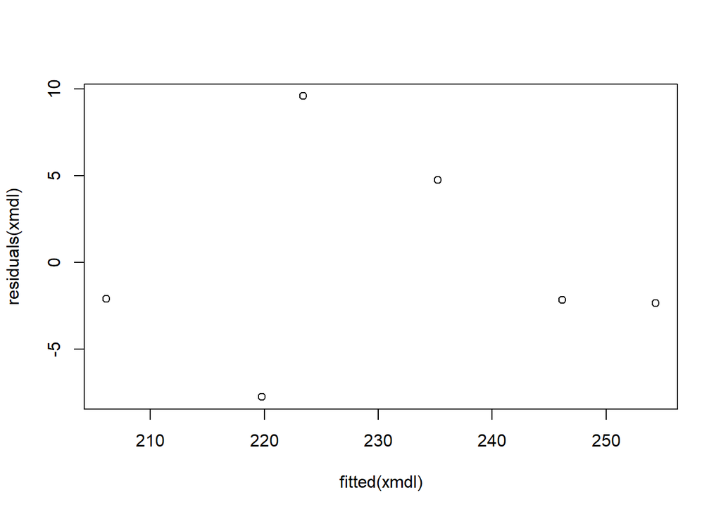

```r
plot(fitted(xmdl),residuals(xmdl))
```

- important to check that there isn’t any obvious pattern in the residuals
- if there is a nonlinear or curvy pattern, this would violate this linearity assumption
- options if your plot indicates nonlinearity
  - check that you haven’t missed an important fixed effect
  - perform a nonlinear transformation of your response (e.g., log-transformation)
  - perform a nonlinear transformation of your fixed effects (e.g., age -> age^2)
  - if you see stripes in your residual plot, you’re most likely dealing with categorical data and you should try a different class of models like logistic models

## 2. Absence of collinearity

- when two fixed effects (predictors) are correlated with each other, they are said to be **collinear**
- collinearity makes the interpretation of the model unstable
- if multiple predictors are very similar to each other, it becomes difficult or impossible to decide which is playing a role in the model, making interpreting the model results hard
- how to get rid of collinearity?
  - if you know you have multiple fixed effects that are similar, think about which one makes the most sense to keep and drop the otheres
  - dimension reduction techniques like principal component analysis (PCA)

## 3. Homoskedasticity or absence of heteroskedasticity

- variance of your data should be approximately equal across the range of your predicted values
- residuals of your model need to have about the same deviation from your predicted values
- if this assumption is violated, you end up with heteroskedasticity or a problem with unequal variances
- a good residual plot pretty much looks like a “blob”
- what to do if the variance is not homoscedastic?
  - transforming your data often helps (e.g., log-transformation)

## 4. Normality of residuals

- data is roughly normally distributed
- arguably the least important assumption
- most linear models are robust against violations of this assumption
- if you want to check this assumption, you can make:
  - a histogram of the residuals (should be relatively bell-shaped)
  - a Q-Q plot (data should fall near the line)

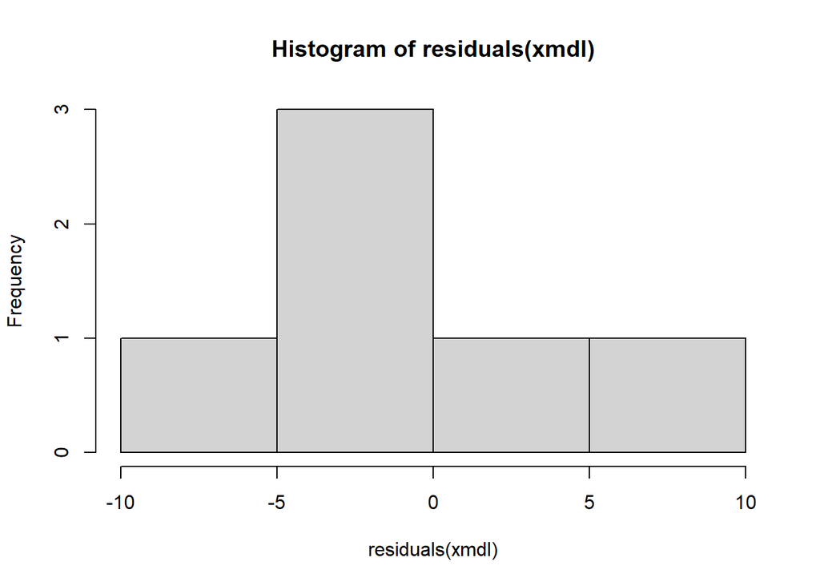

```r
hist(residuals(xmdl))
```

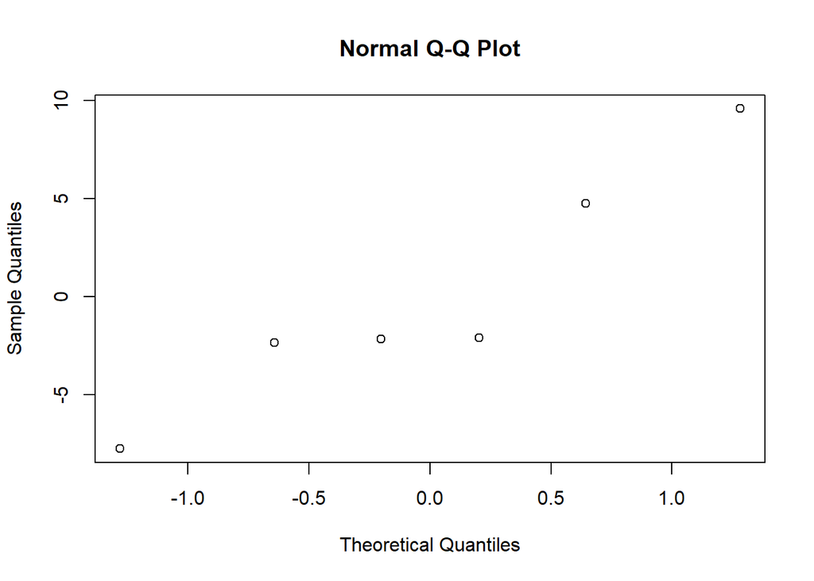

```r
qqnorm(residuals(xmdl))
```

## 5. Absence of influential data points

- can check using `dfbeta()`
- DFbeta values = the values that the coeeficients would have to be adjusted if a particular data point is excluded (aka leave one out diangostics)
- the DFbeta is pretty much how much the slope will change if you leave out any given data point (so closer to 0 the less influential)
- a bit of room for interpretation of what makes a large or small DFbeta value
- any value that changes the sign of the slope is definitely an influential point
- what to do if you have influential data points?
  - good idea to run the model with all the data points and again without the influential points. Report both and say if the interpretation changed at all

```r
dfbeta(xmdl)
```

```
##   (Intercept)       age.c
## 1  -0.8002664  0.06437573
## 2  -0.5220150  0.02736278
## 3   0.9678744 -0.01456709
## 4   2.0026352  0.05092767
## 5  -1.7103247 -0.06479736
## 6  -0.7828787 -0.06622744
```

## 6. Independence

- by far the most important assumption
- every observation must be independent from the others
- data points should come from different subjects and each subject should only contribute one data point

A lot of times we want to collect more data per subject, like in a repeated measures design. If this is the case, you need to resolve these non-independencies at the analysis stage… this is where **mixed models** come in handy.